# Computational Part of Assessment Exercises

Advanced Statistical Inference - Unit 3

Alexander J Ohrt

28 desember, 2021

## Problem 2

### 2.4

The profile log-likelihoods $l_p(\lambda)$ and $l_p(\theta)$ are plotted below.

```r
d1 <- 17
d2 <- 28
d <- d1+d2
Y1 <- 2768.9
Y2 <- 1857.5
n <- 1000
```

First, $l_p(\lambda)$ is plotted.

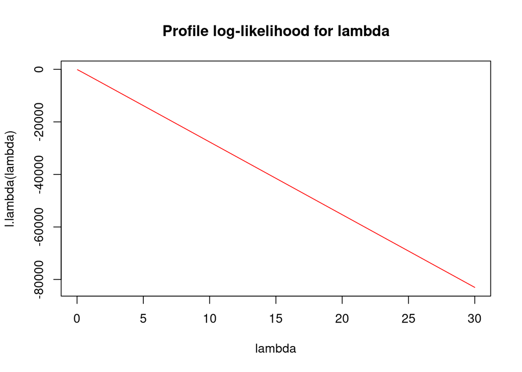

```r
lambda <- seq(0,30, length.out = n)
l.lambda <- function(lambda){
  d1*log(lambda)-lambda*Y1
}
plot(lambda, l.lambda(lambda), ty = "l", main = "Profile log-likelihood for lambda", col = "red")
```

Next, $l_p(\theta)$ is plotted.

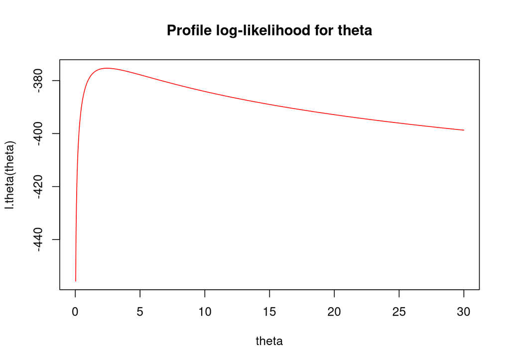

```r
theta <- seq(0, 30, length.out = n)
l.theta <- function(theta){
  -d*log(theta*Y2 + Y1) + d2*log(theta)
}
plot(theta, l.theta(theta), ty = "l", main = "Profile log-likelihood for theta", col = "red", lty = 1)
```

A contour plot of the relative log-likelihood $\tilde{l}(\lambda, \theta)$ is made below.

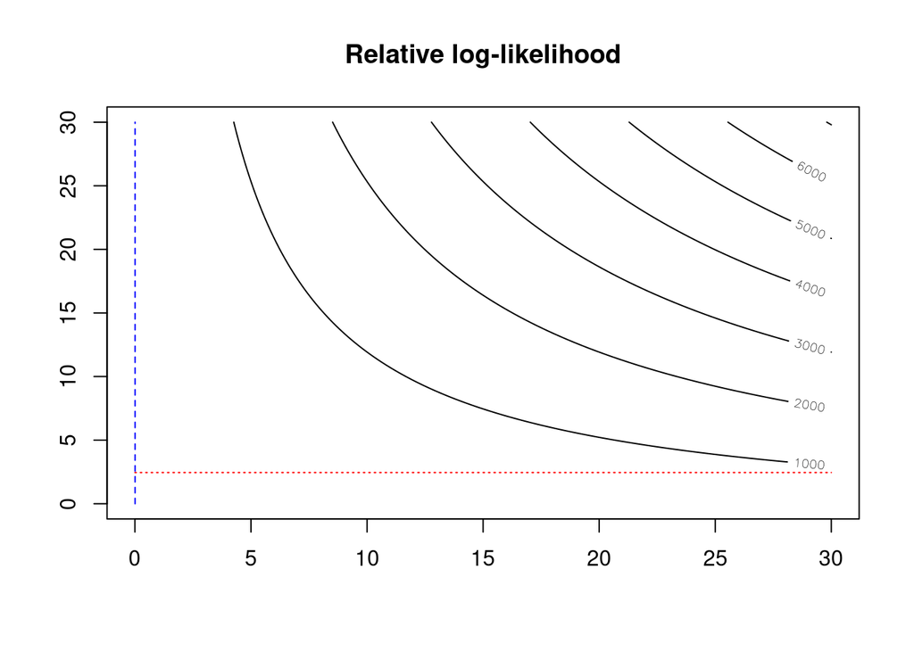

```r
loglik.prob2 <- function(lambda, theta){
  d*log(lambda)+d2*log(theta)-lambda*Y1-theta%o%lambda*Y2
}
lambda.hat <- rep(d1/Y1, length.out = n)
theta.hat <- rep(d2/d1*Y1/Y2, length.out = n)

relative.like <- function(lambda, theta){
  loglik.prob2(lambda, theta)/loglik.prob2(lambda.hat, theta.hat)
}

contour(x = lambda, y = theta, z = relative.like(lambda, theta), main = "Relative log-likelihood")
lines(x = lambda, y = theta.hat, col = "red", lty = 3)
lines(x = lambda.hat, y = theta, col = "blue", lty = 2)
```

The red dotted line represents $(\lambda, \hat{\theta}(\lambda))$ and the blue dotted line represents $(\hat{\lambda}(\theta), \theta)$.

## Problem 3

### 3.4

The Newton-Raphson algorithm is implemented using the expressions obtained analytically.

```r
newton.raphson <- function(sample, it0, eps, maxiter){
  n <- length(sample)
  d1 <- function(iterate){
    # First derivative of log-likelihood.
    return(n/iterate + sum(log(sample)*(1-sample^iterate)))
  }

  d2 <- function(iterate){
    # Second derivative of log-likelihood.
    return(-n/iterate^2 - sum(sample^iterate*(log(sample))^2))
  }

  errest <- 2*eps
  i <- 0
  while (errest > eps && i < maxiter){
    it1 <- it0 - d1(it0)/d2(it0)
    errest <- abs(it1 - it0)
    it0 <- it1
    i <- i + 1
  }

  return(cbind("Fixed Point" = it1, "Iterations" = i, "d2(fixed point)" = d2(it1)))
}
```

### 3.5

Generate samples of size n = 5 from a Weibull distribution with parameters $\alpha = 1$, $\alpha = 2$ and $\alpha = 5$ respectively. Apply the preceding algorithm to obtain a numerical approximation to the value of $\alpha$ in each case. Comment on the difference between the results of each case.

The numerical approximation in each of the cases is given in the table below.

```r
set.seed(1)
n <- 5
alpha_1 <- rweibull(n = n, scale = 1, shape = 1)
alpha_2 <- rweibull(n = n, scale = 1, shape = 2)
alpha_5 <- rweibull(n = n, scale = 1, shape = 5)
eps <- 0.0000000000001
par <- 0.5
s.1 <- newton.raphson(alpha_1, par, eps, 100)
s.2 <- newton.raphson(alpha_2, par, eps, 100)
s.5 <- newton.raphson(alpha_5, par, eps, 100)
results <- rbind(s.1, s.2, s.5)
rownames(results) <- c("alpha = 1", "alpha = 2", "alpha = 5")
knitr::kable(results, caption = "Approx. With Newton-Raphson")
```

Approx. With Newton-Raphson

|  | Fixed Point | Iterations | d2(fixed point) |
| --- | --- | --- | --- |
| alpha = 1 | 1.529233 | 7 | -3.0085875 |
| alpha = 2 | 1.555624 | 7 | -3.2669613 |
| alpha = 5 | 7.847314 | 10 | -0.1442047 |

It is apparent that none of the results are very similar to the true values of $\alpha$. This is largely because we only have $n = 5$ samples in each case. If the sample size is increased, the fixed points come much closer to the true values.

An example of the results after an increased sample size ($n=10000$) can be seen below.

```r
set.seed(1)
n <- 10000
alpha_1.1 <- rweibull(n = n, scale = 1, shape = 1)
alpha_2.1 <- rweibull(n = n, scale = 1, shape = 2)
alpha_5.1 <- rweibull(n = n, scale = 1, shape = 5)
s.bigger.1 <- newton.raphson(alpha_1.1, par, eps, 100)
s.bigger.2 <- newton.raphson(alpha_2.1, par, eps, 100)
s.bigger.5 <- newton.raphson(alpha_5.1, par, eps, 100)
results <- rbind(s.bigger.1, s.bigger.2, s.bigger.5)
rownames(results) <- c("alpha = 1", "alpha = 2", "alpha = 5")
knitr::kable(results, caption = "Approx. After Increasing Sample Size")
```

Approx. After Increasing Sample Size

|  | Fixed Point | Iterations | d2(fixed point) |
| --- | --- | --- | --- |
| alpha = 1 | 0.9887856 | 6 | -18640.8153 |
| alpha = 2 | 2.0053067 | 7 | -4525.0154 |
| alpha = 5 | 5.0528187 | 9 | -719.2562 |

For completeness we check the results, when generating samples of size $n=5$, using the `optim` function. The results are

```r
loglik <- function(alpha, data){
  n <- length(data)
  (n*log(alpha) - sum(data^alpha) + (alpha-1)*sum(log(data)))
}

gr <- function(alpha, data){
  n <- length(data)
  return(n/alpha + sum(log(data)*(1-data^alpha)))
}

res1 <- optim(par = par, fn = loglik, data = alpha_1,
      hessian = T, control = list(fnscale = -1))

res2 <- optim(par = par, fn = loglik, data = alpha_2,
      hessian = T, control = list(fnscale = -1))

res3 <- optim(par = par, fn = loglik, data = alpha_5,
      hessian = T, control = list(fnscale = -1))
results <- rbind(c(res1$par, res1$convergence, res1$hessian),
                 c(res2$par, res2$convergence, res2$hessian),
                 c(res3$par, res3$convergence, res3$hessian))
rownames(results) <- c("alpha = 1", "alpha = 2", "alpha = 5")
colnames(results) <- c("Fixed Point", "Convergence", "Hessian")
knitr::kable(results, caption = "Approx. With Optim.")
```

Approx. With Optim.

|  | Fixed Point | Convergence | Hessian |
| --- | --- | --- | --- |
| alpha = 1 | 1.529297 | 0 | -3.0083988 |
| alpha = 2 | 1.555469 | 0 | -3.2674292 |
| alpha = 5 | 7.846875 | 0 | -0.1442135 |

As is apparent, the `optim` function (using the Nelder-Mead method for maximization) gives very similar results to our implementation.

## Problem 4

Consider 80 observations from a multinomial model with three cells governed by a parameter $p \in (0,.2)$

| Cell | 1 | 2 | 3 |
| --- | --- | --- | --- |
| Probability | $p + 0.2$ | $p + 0.4$ | $0.4 - 2p$ |
| Frequencies | 20 | 50 | 10 |

Use the EM algorithm to approximate the MLE of $p$. Take $p_0 = 0.1$ as the initial value.

First of all I will calculate the explicit log-likelihood function for this problem and maximize it. After this, we will see that the EM algorithm approximates the result.

```r
y1 <- 20
y2 <- 50
y3 <- 10
```

Since we know that this is a multinomial model, the joint density of the observations is

$$f(\mathbf{y}|p) = \frac{n!}{y_1!y_2!y_3!} (p+0.2)^{y_1}(p+0.4)^{y_2}(0.4-2p)^{y_3}.$$

Thus, the log-likelihood function is

$$l(p|\mathbf{y}) = y_1\log(p+0.2) + y_2\log(p+0.4) + y_3\log(0.4-2p),$$

when we ignore the factors that do not depend on $p$. This can be maximized analytically, which requires some tedious computation. Instead, it is maximized numerically, via the `optimize` function. The result is

```r
# Maximize the analytical function (numerically) to check results.
analytic.lik <- function(p){
  return(y1*log(p+0.2) + y2*log(p+0.4)+y3*log(0.4-2*p))
}
ana <- optimize(analytic.lik, interval = c(0,0.2), maximum = T)
ana$maximum
```

```
## [1] 0.1347558
```

where the value of the objective function in the maximum is -73.5490431. As inspired by some [lecture notes](https://www.math.kth.se/matstat/gru/Statistical%20inference/Lecture8.pdf) from KTH on the EM algorithm, let us imagine that we have four cells instead of three by splitting the first cell into two. Thus, we have the table

| Cell | 1.1 | 1.2 | 2 | 3 |
| --- | --- | --- | --- | --- |
| Probability | $p$ | $0.2$ | $p + 0.4$ | $0.4 - 2p$ |
| Frequencies | ? | ? | 50 | 10 |

where we no longer know the exact frequency in cell 1.1 and 1.2. We only know that $y_{1.1} + y_{1.2} = y_1 = 20$. The joint density with this model in mind is

$$f_2(\mathbf{y}|p) = \frac{n!}{y_{1.1}!y_{1.2}!y_2!y_3!} p^{y_{1.1}}0.2^{y_{1.2}}(p+0.4)^{y_2}(0.4-2p)^{y_3},$$

which gives the log-likelihood function

$$l_2(p|\mathbf{y}) = y_{1.1}\log(p) + y_2\log(p+0.4) + y_3\log(0.4-2p).$$

This cannot be maximized, since $y_{1.1}$ is a latent variable. This is where the EM algorithm comes into play. Set the initial guess $p^{(0)} = 0.1$. In the first $\textit{expectation}$-step (E-step) we calculate

$$Q(p|p^{(0)}) = \text{E}_{p^{(0)}}[l_2(p|\mathbf{Y})|Y_1, Y_2, Y_3],$$

i.e. the expectation of the log-likelihood function given the observed variables, with respect to the initial guess for the parameter $p$. In the $\textit{maximization}$-step (M-step) the guess for $p$ will be updated by maximizing the expectation found in the E-step. Going back to the E-step, the value is calculated by noting that $Y_{1.1}|Y_1 \sim Bin(n = Y_1, p = \frac{p^{(0)}}{p^{(0)}+0.2})$ for the first step. Thus, we get

$$\begin{align}
Q(p|p^{(0)}) &= \text{E}_{p^{(0)}}[l_2(p|\mathbf{Y})|Y_1, Y_2, Y_3] \\
&= \text{E}_{p^{(0)}}[Y_{1.1}|Y_1]\log(p) + Y_2\log(p+0.4)+Y_3\log(0.4-2p) \\
&= \frac{Y_1p^{(0)}}{p^{(0)} + 0.2}\log(p) + Y_2\log(p+0.4)+Y_3\log(0.4-2p) \\
&= y_{1.1}^{(0)}\log(p) + Y_2\log(p+0.4)+Y_3\log(0.4-2p),
\end{align}$$

where we have defined $y_{1.1}^{(0)} := \frac{Y_1p^{(0)}}{p^{(0)} + 0.2}$. As already noted, the expectation $Q(p|p^{(0)})$ is maximized with respect to $p$ in the M-step, in order to find the new guess for $p$, $p^{(1)}$. The final iteration takes the form

$$\begin{align}
y_{1.1}^{(i)} &= \frac{Y_1p^{(i)}}{p^{(i)} + 0.2},\\
p^{(i+1)} &= \max_{p}Q(p|p^{(i)}) = \max_{p} y_{1.1}^{(i)}\log(p) + Y_2\log(p+0.4)+Y_3\log(0.4-2p).
\end{align}$$

This is what is implemented in R, to approximate the MLE of $p$. As for the maximization done in the first case, it is done via the function `optimize` here as well, since analytic maximization is tedious. The iteration is stopped when the difference between consecutive values of $p^{(i)}$ reaches some (low) tolerance level. The results are shown below.

```r
p0 <- 0.1 # Initial value

# E-step.
E <- function(p0){
    return((y1*p0)/(p0+0.2))
}
# M-step.
M <- function(p0, expe){
  l <- function(p){
    return(expe*log(p)+y2*log(p+0.4)+y3*log(0.4-2*p))
  }
  m <- optimize(l, interval = c(0,0.2), maximum = T)
  return(m$maximum)
}

# Fixed point iterations.
EM <- function(p0, maxiter, tol){
  errest <- 2*tol
  i <- 0
  ps <- c(p0)
  while (errest > tol && i < maxiter){
    expe <- E(p0)
    p1 <- M(p0, expe)
    ps <- c(ps, p1)
    errest <- abs(p1-p0)
    p0 <- p1
    i <- i + 1
  }
  return(list(ps, p1, i))
}

maxiter <- 100
tol <- 0.000000000000001
results <- EM(p0, maxiter, tol)

knitr::kable(data.frame("Value" = results[[1]]), row.names = 1:results[[3]], caption = "Values of p in each Iteration")
```

Values of p in each Iteration

|  | Value |
| --- | --- |
| 1 | 0.1000000 |
| 2 | 0.1310531 |
| 3 | 0.1344163 |
| 4 | 0.1347221 |
| 5 | 0.1347495 |
| 6 | 0.1347519 |
| 7 | 0.1347521 |
| 8 | 0.1347521 |
| 9 | 0.1347521 |
| 10 | 0.1347521 |
| 11 | 0.1347521 |
| 12 | 0.1347521 |
| 13 | 0.1347521 |
| 14 | 0.1347521 |
| 15 | 0.1347521 |
| 16 | 0.1347521 |

As we can see, the approximated value to the MLE of $p$ is 0.1347521, and the objective function at this value is -73.549043. Comparing with the first solution, as shown in the table below, we see that they are very similar.

```r
df <- cbind("First Max." = c(ana$maximum, ana$objective), "EM" = c(results[[2]], analytic.lik(results[[2]])))
rownames(df) <- c("MLE approx. of p", "Objective Value")
knitr::kable(df, caption = "Comparison of Analytic Maximization and EM")
```

Comparison of Analytic Maximization and EM

|  | First Max. | EM |
| --- | --- | --- |
| MLE approx. of p | 0.1347558 | 0.1347521 |
| Objective Value | -73.5490431 | -73.5490430 |